# Clinical report

[figure not shown]

Dr. Marsh K??nigs, m.konigs@amc.nl

##Attention Network Test

Personal details

| Personal | Details |
| --- | --- |
| Diet | NA |
| Condition, else | NA |
| Medication | NA |
| Medication | NA |

Test details

| Test | Details |
| --- | --- |
| OS Version | 3.1.9 |
| Test Version | Attention_v1.2.osexp |
| Measurement Type | Regulier |
| Date and time | 06/15/22 15:14:19 |
| Backend | xpyriment |

###Timeline of Task Performance

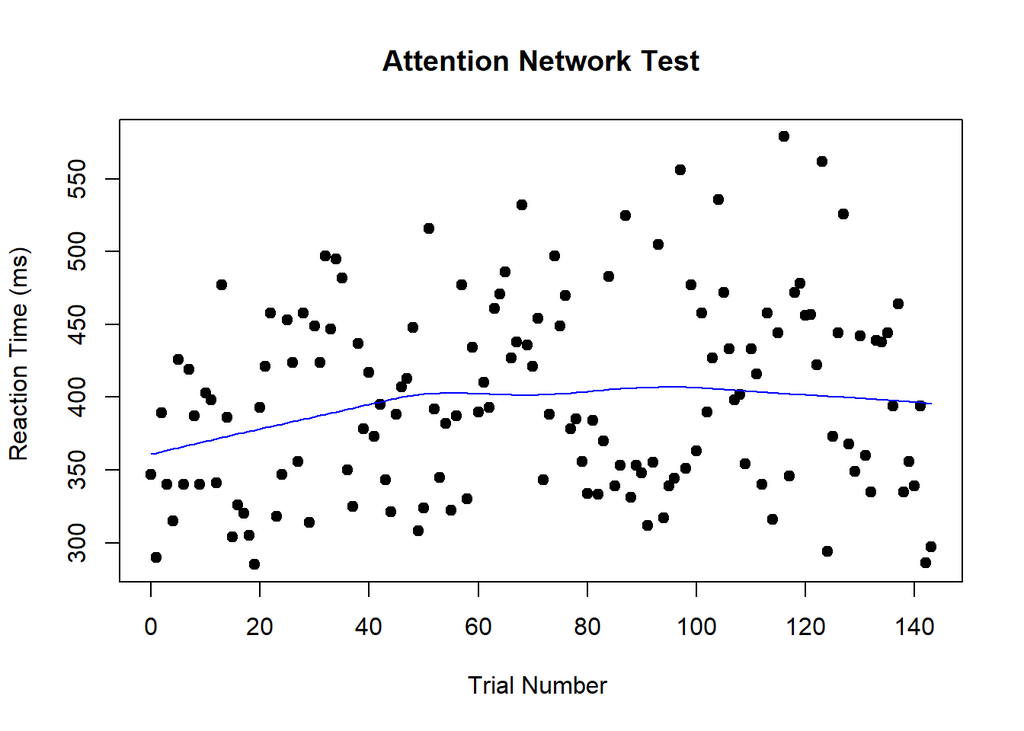

**Legend.** Timeline of task performance, showing reaction time in correct responses as a function of trial number. A loess curve indicates the trend over time.

###Simple Information Processing

###Global Information Processing

Information Processing

[output not shown]

**Legend.** Reaction times are based on correct responses. Mean Reaction Time: speed of processing SD of Reaction Time: variability of processing Accuracy: quality of processing

###Attention Networks

Attention Networks

[output not shown]

**Legend.** Attention networks are based on Posner’s model. Alerting attention is the ability to achieve and maintain an alert state. Orienting attention is the ability to spatielly orient to environmental information. Executive attention is the ability to resolve conflict between competing responses.

###Ex-Gaussian Analysis of Attention Network Test

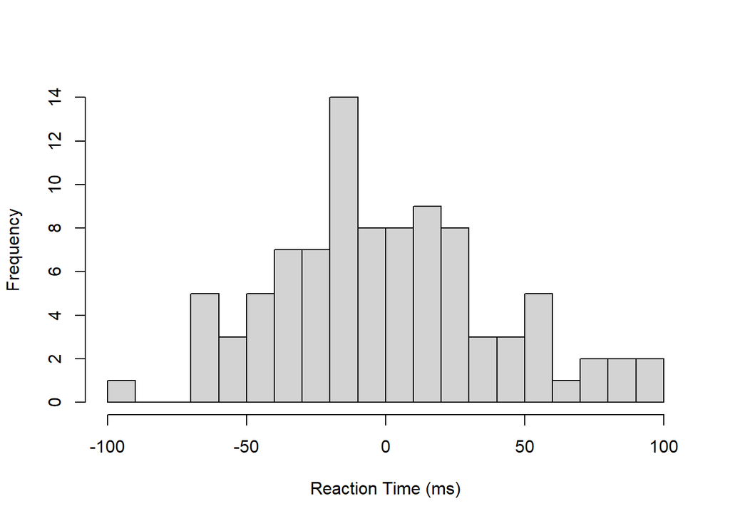

Ex-Gaussian Parameters

[output not shown]

**Legend.** Ex-Gaussian parameters were calculated across all task conditions. Mu: mean reaction time (ms), corrected for lapses of attention. Sigma: standard deviation of reaction time (ms), corrected for lapses of attention. Tau: lapses of attention, or the influence of extreme slow responses on reaction time.